# stats701_homework_8

## Stats701 Homework 8 Winter 2018

### Yunbin Peng

#### yunbpeng@umich.edu

```python
import re
from bs4 import BeautifulSoup
import urllib.request
import sqlite3
import numpy as np
import matplotlib.pyplot as plt
```

## Problem 1 Regular Expressions

### Part 1

```python
response = urllib.request.urlopen("http://www.greenteapress.com/thinkpython/code/words.txt")
count = 0
lst = []
for word in response:
    count = count + 1
    lst.append(word.decode().strip())
count
```

```
113809
```

There are **113809** words in the file.

### Part 2

**Singular and plural forms of a word are all included, for example actor and actors. All words are in lower case.**

### Part 3

```python
result1 = []
for i in lst:
    if ((re.match(r'^[^aeiouy]{4}[aeiouy].*', i) is None) != True) or ((re.match(r'^[^aeiouy]{4}$', i) is None) != True):
        result1.append(i)
```

```python
len(result1)
```

```
60
```

There are **60** words

### Part 4

```python
result2 = []
for i in lst:
    if (re.match(r'^[^a]*a[^a]*a[^a]*a[^a]*a', i) is None) != True:
        result2.append(i)
```

```python
len(result2)
```

```
50
```

There are **50** words.

### Part 5

```python
result3 = []
for i in lst:
    if (re.match(r'^[aeiou][^aeiouy]+[aeiou]$', i) is None) != True:
        result3.append(i)
```

```python
len(result3)
```

```
165
```

There are **165** words

### Part 6

```python
result4 = []
for i in lst:
    if (re.match(r'^(.{2}).*(\1)$', i) is None) != True:
        result4.append(i)
    elif (re.match(r'^(..)$', i) is None) != True:
        result4.append(i)
    elif (re.match(r'^(.)(\1)(\1)$', i) is None) != True:
        result4.append(i)
```

```python
len(result4)
```

```
366
```

There are **366** words if you also count any 2-letter words (for example at, ay) as starting and ending with the samw 2-letter sequence.

## Problem 2 Exploring Internet Traffic with Regexes

### Part 1

```python
f = open("SkypeIRC.txt", encoding = "utf-8")
```

```python
text_2 = f.read()
```

```python
result2_1 = text_2.split("\n")
len(result2_1)-1 #last entry is an empty string
```

```
2263
```

There are 2263 packets

### Part 2

```python
result2_2 = re.findall('\d+\.\d+\.\d+\.\d+', text_2)
```

```python
len(result2_2)
```

```
5048
```

```python
len(set(result2_2))
```

```
368
```

There are 368 unique IP addresses

### Part 3

```python
search2_3 = re.findall(r'([\w.-]+).comcast.net', text_2)
```

```python
result2_3 = list(set(search2_3))
```

```python
result2_3
```

```
['c-24-22-73-206.hsd1.mn',
 'c-67-190-177-7.hsd1.co',
 'c-67-163-59-104.hsd1.il',
 'c-68-84-140-103.hsd1.md',
 'c-68-55-27-139.hsd1.md',
 'c-67-190-60-125.hsd1.co',
 'c-24-125-186-144.hsd1.va',
 'c-71-228-44-157.hsd1.il',
 'c-71-196-236-185.hsd1.co',
 'c-69-248-108-13.hsd1.pa',
 'c-68-32-70-119.hsd1.ga',
 'c-67-175-21-149.hsd1.in',
 'c-69-244-172-248.hsd1.mi',
 'c-69-250-183-56.hsd1.md',
 'c-24-22-73-206.hsd1.or',
 'c-68-51-91-234.hsd1.in',
 'c-69-141-46-5.hsd1.nj',
 'c-67-162-133-209.hsd1.co',
 'c-68-38-164-187.hsd1.nj',
 'c-68-47-20-134.hsd1.ga',
 'c-67-163-96-170.hsd1.tx',
 'c-67-188-114-72.hsd1.ca',
 'c-67-165-90-216.hsd1.oh',
 'c-68-53-93-55.hsd1.ky',
 'c-24-61-5-13.hsd1.ma']
```

```python
len(result2_3)
```

```
25
```

There are **25** unique servers.

### Part 4

```python
search2_4 = re.findall(r'\d+\s+(\d+\.\d+)\s+\d+\.\d+\.\d+\.\d+', text_2)
```

```python
time_stamp = np.array(search2_4).astype(np.float)
time_stamp
```

```
array([0.00000000e+00, 1.25852000e-01, 1.37361000e-01, ...,
       3.22654975e+02, 3.22749725e+02, 3.22749776e+02])
```

```python
time_stamp.max()
```

```
322.749776
```

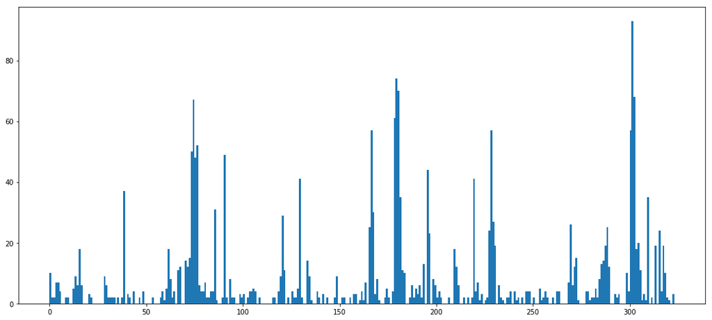

```python
plt.figure(figsize=(18, 8))
(n, bins, patches) = plt.hist(time_stamp, bins = np.arange(323+1))
```

## Problem 3

### Part 1

```python
response = urllib.request.urlopen('https://en.wikipedia.org/wiki/Ann_Arbor,_Michigan')
```

```python
parsed = BeautifulSoup(response, 'html.parser')
```

The climate table has **12** children, all of them are **"tr"** tag ("" should be <> in html). Each child ("tr" tag) except the 1st and the last one has 13 descendants (1 "th" tag and 12 "td" tags)

### Part 2

```python
def retrieve_climate_table(url):
    try:
        response = urllib.request.urlopen(url)

        parsed = BeautifulSoup(response, 'html.parser')
        tables = parsed.find_all("table", class_="wikitable")

        climate_table = None

        if len(tables) == 0:
            climate_table = None
        elif len(tables) == 1:
            tables1 = parsed.find("table", class_="wikitable")
            if "Climate" in tables1.find("th").text:
                climate_table = tables1
            elif "Climate" in tables1.find("caption").text:
                climate_table = tables1
        elif len(tables) > 1:
            for i in range(len(tables)):
                if "Climate" in tables[i].find("th").get_text():
                    climate_table = tables[i]
        return(climate_table)
    except:
        print("Error: Website cannot be opened")
```

```python
retrieve_climate_table('https://en.wikipedia.org/wiki/Ann_Arbor,_Michigan')
```

```
<table class="wikitable collapsible" style="width:90%; text-align:center; font-size:90%; line-height: 1.2em; margin:auto;">
<tr>
<th colspan="14">Climate data for Ann Arbor, Michigan (UMich, 1981–2010)</th>
</tr>
<tr>
<th scope="row">Month</th>
<th scope="col">Jan</th>
<th scope="col">Feb</th>
<th scope="col">Mar</th>
<th scope="col">Apr</th>
<th scope="col">May</th>
<th scope="col">Jun</th>
<th scope="col">Jul</th>
<th scope="col">Aug</th>
<th scope="col">Sep</th>
<th scope="col">Oct</th>
<th scope="col">Nov</th>
<th scope="col">Dec</th>
<th scope="col" style="border-left-width:medium">Year</th>
</tr>
<tr style="text-align: center;">
<th scope="row" style="height: 16px;">Record high °F (°C)</th>
<td style="background: #FF860D; color:#000000;">72<br/>
(22)</td>
<td style="background: #FF9B37; color:#000000;">67<br/>
(19)</td>
<td style="background: #FF5600; color:#000000;">85<br/>
(29)</td>
<td style="background: #FF4800; color:#000000;">88<br/>
(31)</td>
<td style="background: #FF2C00; color:#000000;">95<br/>
(35)</td>
<td style="background: #FF1100; color:#FFFFFF;">103<br/>
(39)</td>
<td style="background: #FF0300; color:#FFFFFF;">105<br/>
(41)</td>
<td style="background: #FF0A00; color:#FFFFFF;">104<br/>
(40)</td>
<td style="background: #FF1F00; color:#000000;">99<br/>
(37)</td>
```

[output cut: 204 more lines]

```
<td style="background: #DFDFFF; color:#000000;">2.5</td>
<td style="background: #FFFFFF; color:#000000;">0</td>
<td style="background: #FFFFFF; color:#000000;">0</td>
<td style="background: #FFFFFF; color:#000000;">0</td>
<td style="background: #FFFFFF; color:#000000;">0</td>
<td style="background: #FFFFFF; color:#000000;">0</td>
<td style="background: #F8F8FF; color:#000000;">0.5</td>
<td style="background: #C5C5FF; color:#000000;">4.5</td>
<td style="background: #6969FF; color:#000000;">12.1</td>
<td style="background: #C7C7FF; color:#000000; border-left-width:medium">53.2</td>
</tr>
<tr>
<td colspan="14" style="text-align:center;font-size:95%;">Source: NOAA<sup class="reference" id="cite_ref-NOAA_45-3"><a href="#cite_note-NOAA-45">[45]</a></sup><sup class="reference" id="cite_ref-46"><a href="#cite_note-46">[46]</a></sup></td>
</tr>
</table>
```

```python
retrieve_climate_table("https://en.wikipedia.org/wiki/San_Diego")
```

```
<table class="wikitable collapsible collapsed" style="width:90%; text-align:center; font-size:90%; line-height: 1.2em; margin:auto;">
<tr>
<th colspan="14">Climate data for <a href="/wiki/San_Diego_International_Airport" title="San Diego International Airport">San Diego Int'l Airport</a> (1981–2010 normals,<sup class="reference" id="cite_ref-79"><a href="#cite_note-79">[a]</a></sup> extremes 1874–present)<sup class="reference" id="cite…
</tr>
<tr>
<th scope="row">Month</th>
<th scope="col">Jan</th>
<th scope="col">Feb</th>
<th scope="col">Mar</th>
<th scope="col">Apr</th>
<th scope="col">May</th>
<th scope="col">Jun</th>
<th scope="col">Jul</th>
<th scope="col">Aug</th>
<th scope="col">Sep</th>
<th scope="col">Oct</th>
<th scope="col">Nov</th>
<th scope="col">Dec</th>
<th scope="col" style="border-left-width:medium">Year</th>
</tr>
<tr style="text-align: center;">
<th scope="row" style="height: 16px;">Record high °F (°C)</th>
<td style="background: #FF4800; color:#000000;">88<br/>
(31)</td>
<td style="background: #FF4100; color:#000000;">90<br/>
(32)</td>
<td style="background: #FF1F00; color:#000000;">99<br/>
(37)</td>
<td style="background: #FF1F00; color:#000000;">98<br/>
(37)</td>
<td style="background: #FF1F00; color:#000000;">98<br/>
(37)</td>
<td style="background: #FF1800; color:#FFFFFF;">101<br/>
(38)</td>
<td style="background: #FF1800; color:#FFFFFF;">100<br/>
(38)</td>
<td style="background: #FF1F00; color:#000000;">98<br/>
(37)</td>
<td style="background: #DC0000; color:#FFFFFF;">111<br/>
(44)</td>
```

[output cut: 236 more lines]

```
<td style="background: #FFFF88; color:#000000;">71</td>
<td style="background: #FFFF53; color:#000000;">58</td>
<td style="background: #FFFF4F; color:#000000;">57</td>
<td style="background: #FFFF84; color:#000000;">70</td>
<td style="background: #FFFF88; color:#000000;">71</td>
<td style="background: #FFFF7C; color:#000000;">68</td>
<td style="background: #FFFF80; color:#000000;">69</td>
<td style="background: #FFFF90; color:#000000;">73</td>
<td style="background: #FFFF94; color:#000000;">74</td>
<td style="background: #FFFF80; color:#000000; border-left-width:medium">69</td>
</tr>
<tr>
<td colspan="14" style="text-align:center;font-size:95%;">Source: NOAA (sun and relative humidity 1961–1990)<sup class="reference" id="cite_ref-82"><a href="#cite_note-82">[80]</a></sup><sup class="reference" id="cite_ref-83"><a href="#cite_note-83">[81]</a></sup><sup class="reference" id="cite_ref-…
</tr>
</table>
```

```python
retrieve_climate_table("http://www.math.ucsd.edu/~jbalog/teach/109_S10/math109_S10.html")
```

```
Error: Website cannot be opened
```

### Part 3

```python
def list_climate_table_row_names(url):
    try:
        response = urllib.request.urlopen(url)

        parsed = BeautifulSoup(response, 'html.parser')
        tables = parsed.find_all("table", class_="wikitable")

        climate_table = None

        if len(tables) == 0:
            climate_table = None
        elif len(tables) == 1:
            tables1 = parsed.find("table", class_="wikitable")
            if "Climate" in tables1.find("th").text:
                climate_table = tables1
            elif "Climate" in tables1.find("caption").text:
                climate_table = tables1
        elif len(tables) > 1:
            for i in range(len(tables)):
                if "Climate" in tables[i].find("th").get_text():
                    climate_table = tables[i]

        # Get row names from the climate table
        row = []
        row_raw = climate_table.find_all("th", scope = "row")
        for i in row_raw:
            row.append(i.get_text())
        return(row)

    except:
        return(None)
```

```python
list_climate_table_row_names("https://en.wikipedia.org/wiki/Ann_Arbor,_Michigan")
```

```
['Month',
 'Record high °F (°C)',
 'Average high °F (°C)',
 'Daily mean °F (°C)',
 'Average low °F (°C)',
 'Record low °F (°C)',
 'Average precipitation inches (mm)',
 'Average snowfall inches (cm)',
 'Average precipitation days (≥ 0.01 in)',
 'Average snowy days (≥ 0.1 in)']
```

```python
list_climate_table_row_names("https://en.wikipedia.org/wiki/Harbin")
```

```
['Month',
 'Record high °C (°F)',
 'Average high °C (°F)',
 'Daily mean °C (°F)',
 'Average low °C (°F)',
 'Record low °C (°F)',
 'Average precipitation mm (inches)',
 'Average precipitation days (≥ 0.1 mm)',
 'Average relative humidity (%)',
 'Mean monthly sunshine hours',
 'Percent possible sunshine']
```

```python
list_climate_table_row_names("https://en.wikipedia.org/wiki/Buenos_Aires")
```

```
['Month',
 'Average high °C (°F)',
 'Daily mean °C (°F)',
 'Average low °C (°F)',
 'Average precipitation mm (inches)',
 'Average precipitation days (≥ 0.1 mm)',
 'Mean monthly sunshine hours']
```

```python
list_climate_table_row_names("https://en.wikipedia.org/wiki/Boston")
```

```
['Month',
 'Record high °F (°C)',
 'Mean maximum °F (°C)',
 'Average high °F (°C)',
 'Daily mean °F (°C)',
 'Average low °F (°C)',
 'Mean minimum °F (°C)',
 'Record low °F (°C)',
 'Average precipitation inches (mm)',
 'Average snowfall inches (cm)',
 'Average precipitation days (≥ 0.01 in)',
 'Average snowy days (≥ 0.1 in)',
 'Average relative humidity (%)',
 'Mean monthly sunshine hours',
 'Percent possible sunshine']
```

```python
list_climate_table_row_names("https://en.wikipedia.org/wiki/Los_Angeles")
```

```
['Month',
 'Record high °F (°C)',
 'Average high °F (°C)',
 'Daily mean °F (°C)',
 'Average low °F (°C)',
 'Record low °F (°C)',
 'Average rainfall inches (mm)',
 'Average rainy days']
```

```python
list_climate_table_row_names("https://en.wikipedia.org/wiki/Hyderabad")
```

```
['Month',
 'Record high °C (°F)',
 'Average high °C (°F)',
 'Daily mean °C (°F)',
 'Average low °C (°F)',
 'Record low °C (°F)',
 'Average rainfall mm (inches)',
 'Average rainy days (≥ 1.0 mm)',
 'Average relative humidity (%)',
 'Mean monthly sunshine hours']
```

```python
list_climate_table_row_names("https://en.wikipedia.org/wiki/Singapore")
```

```
['Month',
 'Record high °C (°F)',
 'Average high °C (°F)',
 'Daily mean °C (°F)',
 'Average low °C (°F)',
 'Record low °C (°F)',
 'Average rainfall mm (inches)',
 'Average rainy days',
 'Average relative humidity (%)',
 'Mean monthly sunshine hours']
```

```python
list_climate_table_row_names("https://en.wikipedia.org/wiki/Nanping")
```

```
['Month',
 'Record high °C (°F)',
 'Average high °C (°F)',
 'Daily mean °C (°F)',
 'Average low °C (°F)',
 'Record low °C (°F)',
 'Average precipitation mm (inches)',
 'Average precipitation days (≥ 0.1 mm)',
 'Average relative humidity (%)',
 'Mean monthly sunshine hours',
 'Percent possible sunshine']
```

```python
list_climate_table_row_names("https://en.wikipedia.org/wiki/Umich")
```

```python
list_climate_table_row_names("https://google.com")
```

```python
list_climate_table_row_names("abc")
```

### Part 4

For example the argument is Ann Arbor Wikipedia url and row name "Record low °C (°F)"  
Step 1: Use *retrieve_climate_table* function to get climate data table of Ann Arbor in html format.  
Step 2: use findall function on the Ann Arbor table from step 1 to find the "tr" tag (row data) whose "th" tag (aka row name) has content (using get_text method) corresponding to the row name in the argument "Record low °C (°F)".  
Step 3: use findall function on the "tr" tag (row data) from step 2 to look for all "td" tags (which are cells in that row except the row name), then use get_text() method to get all "td" tag contents, they are all the data in the table in the row whose name matches with the provided argument.

## Problem 4 Relational Databases and SQL

### Part 1 & 2

```python
conn = sqlite3.connect('Chinook_Sqlite.sqlite')
```

```python
c = conn.cursor()
```

```python
count = 0
for r in c.execute("SELECT name FROM sqlite_master WHERE type='table'"):
    count += 1
    print(r)
print(count)
```

```
('Album',)
('Artist',)
('Customer',)
('Employee',)
('Genre',)
('Invoice',)
('InvoiceLine',)
('MediaType',)
('Playlist',)
('PlaylistTrack',)
('Track',)
11
```

There are **11** tables, their names are **Album, Artist, Customer, Employee, Genre, Invoice, InvoiceLine, MediaType, Playlist, PlaylistTrack, and Track**.

### Part 3

```python
c.execute('''SELECT * FROM Album''')
[desc[0] for desc in c.description]
```

```
['AlbumId', 'Title', 'ArtistId']
```

```python
for row in c.execute('''SELECT AlbumID, Title FROM Album WHERE Title LIKE 'A%' '''):
    print(row)
```

```
(10, 'Audioslave')
(14, 'Alcohol Fueled Brewtality Live! [Disc 1]')
(15, 'Alcohol Fueled Brewtality Live! [Disc 2]')
(24, 'Afrociberdelia')
(26, 'Acústico MTV [Live]')
(29, 'Axé Bahia 2001')
(74, 'Album Of The Year')
(75, 'Angel Dust')
(85, 'As Canções de Eu Tu Eles')
(89, 'American Idiot')
(90, 'Appetite for Destruction')
(94, 'A Matter of Life and Death')
(95, 'A Real Dead One')
(96, 'A Real Live One')
(120, 'Are You Experienced?')
(139, 'A TempestadeTempestade Ou O Livro Dos Dias')
(160, 'Ace Of Spades')
(167, 'Acústico MTV')
(168, 'Arquivo II')
(169, 'Arquivo Os Paralamas Do Sucesso')
(203, 'A-Sides')
(224, 'Acústico')
(232, 'Achtung Baby')
(233, "All That You Can't Leave Behind")
(248, 'Ao Vivo [IMPORT]')
(254, 'Aquaman')
(272, 'Adorate Deum: Gregorian Chant from the Proper of the Mass')
(273, 'Allegri: Miserere')
(285, 'A Soprano Inspired')
(296, 'A Copland Celebration, Vol. I')
(307, 'Adams, John: The Chairman Dances')
(319, 'Armada: Music from the Courts of England and Spain')
```

```python
count = 0
for row in c.execute('''SELECT AlbumID FROM Album WHERE Title LIKE 'E%' '''):
    count += 1
    print(row)
count
```

```
(71,)
(116,)
(265,)
(306,)
(314,)
```

```
5
```

```python
def list_album_ids_by_letter(letter):
    ids = []
    keyletter = (letter + '%',)
    for row in c.execute('''SELECT AlbumID FROM Album WHERE Title LIKE ? ''', keyletter):
        ids.append(row[0])
    return(ids)
```

```python
len(list_album_ids_by_letter('C'))
```

```
23
```

There are **23** albums with titles starting with "C".

```python
len(list_album_ids_by_letter('M'))
```

```
25
```

There are **25** albums with titles starting with "M".

### Part 4

```python
c.execute('''SELECT * FROM Album''')
[desc[0] for desc in c.description]
```

```
['AlbumId', 'Title', 'ArtistId']
```

```python
c.execute('''SELECT * FROM Track''')
[desc[0] for desc in c.description]
```

```
['TrackId',
 'Name',
 'AlbumId',
 'MediaTypeId',
 'GenreId',
 'Composer',
 'Milliseconds',
 'Bytes',
 'UnitPrice']
```

```python
def list_song_ids_by_album_letter(letter):
    ids = []
    keyletter = (letter + '%',)
    for row in c.execute('''SELECT Track.TrackID FROM Album
    INNER JOIN Track ON Album.AlbumID = Track.AlbumId WHERE Title LIKE ?''', keyletter):
        ids.append(row[0])
    return(ids)
```

```python
len(list_song_ids_by_album_letter('N'))
```

```
74
```

```python
len(list_song_ids_by_album_letter('D'))
```

```
106
```

There are **74** songs in albums whose titles start with 'N' and **106** songs in albums whose titles start with 'D'.

### Part 5

```python
keyletter = ('N%', )
```

```python
for row in c.execute('''SELECT sum(Track.UnitPrice) FROM Album
    INNER JOIN Track ON Album.AlbumID = Track.AlbumId WHERE Title LIKE ?''', keyletter):
        print(row[0])
```

```
73.25999999999999
```

```python
def total_cost_by_album_letter(letter):
    cost = 0
    keyletter = (letter + '%',)
    for row in c.execute('''SELECT sum(Track.UnitPrice) FROM Album
    INNER JOIN Track ON Album.AlbumID = Track.AlbumId WHERE Title LIKE ?''', keyletter):
        cost += row[0]
    return(cost)
```

```python
total_cost_by_album_letter('L')
```

```
350.3900000000009
```

It costs $350.39 to buy all tracks in albums begins with 'L'